# dataset_inspection

```python
import pandas as pd
import numpy as np
import matplotlib.pyplot as plt
from collections import Counter

import warnings
warnings.filterwarnings("ignore")

df = pd.read_csv('/home/losmi/faks/som/11_hepatitis_c_dataset.csv')
```

### Primitive data visualization

```python
df.info()
```

```
<class 'pandas.core.frame.DataFrame'>
RangeIndex: 615 entries, 0 to 614
Data columns (total 13 columns):
 #   Column    Non-Null Count  Dtype
---  ------    --------------  -----
 0   Category  615 non-null    object
 1   Age       615 non-null    int64
 2   Sex       615 non-null    object
 3   ALB       615 non-null    object
 4   ALP       615 non-null    object
 5   ALT       615 non-null    object
 6   AST       615 non-null    float64
 7   BIL       615 non-null    float64
 8   CHE       615 non-null    float64
 9   CHOL      615 non-null    object
 10  CREA      615 non-null    float64
 11  GGT       615 non-null    float64
 12  PROT      615 non-null    object
dtypes: float64(5), int64(1), object(7)
memory usage: 62.6+ KB
```

```python
cols = ['Age', 'ALB', 'ALP', 'ALT', 'AST', 'BIL', 'CHE', 'CHOL', 'CREA', 'GGT', 'PROT']
chars = (df[cols].astype(str).apply(lambda x: x.str.findall(r'[^0-9]')).sum().sum())

char_counts = Counter(chars)
for ch, cnt in char_counts.items():
    print(f'{ch}: {cnt}')
```

```
.: 5756
?: 31
```

```python
q_mark_per_col = df.astype(str).apply(lambda x: x.str.count(r'\?').sum())
print(q_mark_per_col)
```

```
Category     0
Age          0
Sex          0
ALB          1
ALP         18
ALT          1
AST          0
BIL          0
CHE          0
CHOL        10
CREA         0
GGT          0
PROT         1
dtype: int64
```

```python
flts = ['ALB','ALP','ALT','AST','BIL','CHE','CHOL','CREA','GGT','PROT']

df[flts] = df[flts].apply(lambda x: pd.to_numeric(x, errors='coerce'))
df.info()
```

```
<class 'pandas.core.frame.DataFrame'>
RangeIndex: 615 entries, 0 to 614
Data columns (total 13 columns):
 #   Column    Non-Null Count  Dtype
---  ------    --------------  -----
 0   Category  615 non-null    object
 1   Age       615 non-null    int64
 2   Sex       615 non-null    object
 3   ALB       614 non-null    float64
 4   ALP       597 non-null    float64
 5   ALT       614 non-null    float64
 6   AST       615 non-null    float64
 7   BIL       615 non-null    float64
 8   CHE       615 non-null    float64
 9   CHOL      605 non-null    float64
 10  CREA      615 non-null    float64
 11  GGT       615 non-null    float64
 12  PROT      614 non-null    float64
dtypes: float64(10), int64(1), object(2)
memory usage: 62.6+ KB
```

Our dataset has 13 columns, of which 11 should be numerical and 2 categorical (gender and category). We see that invalid samples come exclusively from `?`. Since the percentage of invalid samples is small compared to the total number of instances, we will replace the invalid samples with the appropriate statistical estimators of the mean, depending on the distributional characteristics of the attribute they belong to.

### Statistical analysis

```python
df['Sex'].value_counts(dropna=False)
```

```
Sex
m    377
f    238
Name: count, dtype: int64
```

```python
df['Category'].value_counts(dropna=False)
```

```
Category
0=Blood Donor             533
3=Cirrhosis                30
1=Hepatitis                24
2=Fibrosis                 21
0s=suspect Blood Donor      7
Name: count, dtype: int64
```

```
array([[<Axes: title={'center': 'ALB'}>, <Axes: title={'center': 'ALP'}>,
        <Axes: title={'center': 'ALT'}>],
       [<Axes: title={'center': 'AST'}>, <Axes: title={'center': 'BIL'}>,
        <Axes: title={'center': 'CHE'}>],
       [<Axes: title={'center': 'CHOL'}>,
        <Axes: title={'center': 'CREA'}>,
        <Axes: title={'center': 'GGT'}>],
       [<Axes: title={'center': 'PROT'}>, <Axes: >, <Axes: >]],
      dtype=object)
```

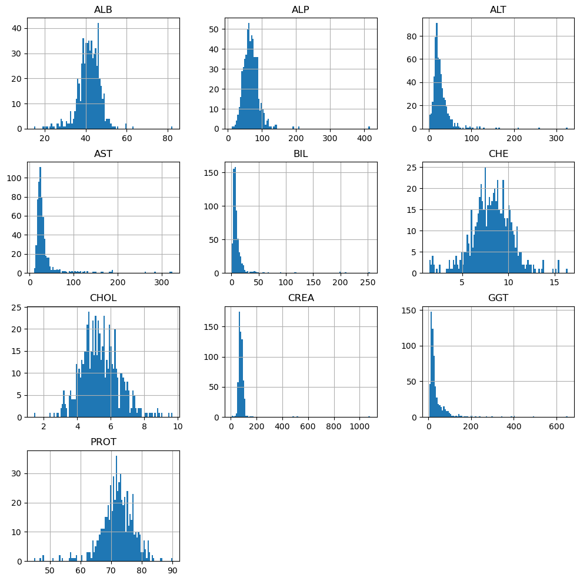

```python
df[flts].hist(bins=100, figsize=(12,12))
```

From the provided plot, we conclude that the distributions of `CHE` and `COL` do not have significant outliers, so we replace invalid samples, if any, with the mean value. On the other hand, for the remaining distributions we observe a non-negligible presence of outliers, so in those cases we perform replacements using the median.

```python
sex_series = df['Sex'].astype(str).str.strip().str.lower()
df['is_male'] = (sex_series == 'm').astype(np.int8)

category_map = {
    "0=Blood Donor": "blood_donor",
    "0s=suspect Blood Donor": "suspect_blood_donor",
    "1=Hepatitis": "hepatitis",
    "2=Fibrosis": "fibrosis",
    "3=Cirrhosis": "cirrhosis",
}
df['category_norm'] = df['Category'].map(category_map).fillna('unknown').astype('category')
df = df[df['category_norm'] != 'suspect_blood_donor'].copy()
df['class'] = df['category_norm'].isin({'hepatitis','fibrosis','cirrhosis'}).astype(np.int8)
```

### Mapping the categorical random variables

We map gender to 0/1, where 1 indicates a male sample and 0 otherwise. This encoding is chosen because the models that use such features transform categorical representations into vector representations. For example, the `Tabular Classifier` class, which is essentially a neural network, maps categorical classes into 3-dimensional vector embeddings that are learned during training. In contrast, models such as `KNN` and `Tree` classifiers convert these categories into distinct one-hot vectors to avoid introducing bias during classification.

```python
means = ['CHE', 'CHOL']
meds = ['ALB', 'ALP', 'ALT','AST','BIL','CREA','GGT','PROT']

mean_vals = df.groupby('category_norm')[means].transform('mean')
df[means] = df[means].fillna(df[means].mean())

med_vals = df.groupby('category_norm')[meds].transform('median')
df[meds] = df[meds].fillna(df[meds].median())
```

### Validity and distributional checks

```python
df[flts].describe().T
```

|  | count | mean | std | min | 25% | 50% | 75% | max |
| --- | --- | --- | --- | --- | --- | --- | --- | --- |
| ALB | 608.0 | 41.819079 | 5.402266 | 20.00 | 39.0000 | 42.00 | 45.225 | 82.20 |
| ALP | 608.0 | 67.767105 | 24.898775 | 11.30 | 52.9000 | 66.00 | 79.025 | 416.60 |
| ALT | 608.0 | 27.593750 | 21.210867 | 0.90 | 16.4000 | 23.00 | 32.675 | 258.00 |
| AST | 608.0 | 34.369408 | 32.622442 | 12.00 | 21.6000 | 25.85 | 32.800 | 324.00 |
| BIL | 608.0 | 11.474013 | 19.770558 | 1.80 | 5.3000 | 7.30 | 11.300 | 254.00 |
| CHE | 608.0 | 8.204885 | 2.168400 | 1.42 | 6.9500 | 8.27 | 9.585 | 16.41 |
| CHOL | 608.0 | 5.378829 | 1.110135 | 1.43 | 4.6275 | 5.31 | 6.060 | 9.67 |
| CREA | 608.0 | 81.513158 | 49.720652 | 8.00 | 68.0000 | 77.00 | 88.000 | 1079.10 |
| GGT | 608.0 | 38.243914 | 51.953220 | 4.50 | 15.7000 | 23.25 | 39.200 | 650.90 |
| PROT | 608.0 | 72.253125 | 4.928188 | 51.00 | 69.4750 | 72.20 | 75.400 | 90.00 |

We see that no invalid values appear; the very small values observed in the table are not invalid, because liver enzyme levels in healthy individuals naturally take low values.

```python
df.isna().sum().sum()
```

```
np.int64(0)
```

We observe no invalid entries.

### EXPORT

```python
df.to_csv('processed.csv')
```